# Pigskin Positions

### By Sanjay Murugesan & Ryan Dillman

### CMSC 320 Final Project

### Overview

- 1. Introduction
     - 1.1 Background Information
     - 1.2 Libraries Used
- 1. Data Collection
     - 2.1 About the dataset
     - 2.2 Load and View Data
     - 2.3 Removing Specialists
     - 2.4 A look into Madden Ratings
- 1. Data Processing
     - 3.1 Positional Breakdown
     - 3.2 Positional Grouping
- 1. Exploratory Data Analysis
     - 4.1 Attribute Categories
     - 4.2 Correlation of Attributes for different positions
     - 4.3 Understanding the correlation
- 1. Machine Learning & Visualization
     - 5.1 Creation and Training of Model
     - 5.2 Plotting to Observe Differences in Predicted and True Frequencies
- 1. Conclusion
     - 6.1 Recap
     - 6.2 Final Thoughts

Note: If you do not have all the libraries we used installed, please install them. The only one we had to additionaly add was for plotly, which you can do so by using the command 'pip install plotly' in a Jupyter terminal window. Once all the required libraries have been installed, please Restart Kernel and Run Again.

### 1. Introduction

In this project we aim to demonstrate our learning and understanding of the data lifecycle by applying it to a real-world situation. Our goal in this tutorial is to try and accurately classify football players into positional groups based on their skills by determining the skills that are most useful for different positions.

#### 1.1 Background Information

America's game, football, is by far the most watched sport in the country and brings in huge amounts of revenue (almost $16 million last season!). All 32 teams competing have the same ultimate goal: to win the Super Bowl. In modern times, NFL teams have used statistical analysis to boost their chances to win in specific situations. NFL players are extremely talented, but are they always being used in the optimum position based on their skillset? In this tutorial, we are going to break down the various skillsets that players of different positions need to succeed, and will take a look at whether or not players are being used at their optimal position.

In order to get this information, we will be using data from the NFL simulation video game 'Madden 20'.

If you are unfamiliar with the different positions in football, we recommend that you read [this short guide, dummy](https://www.dummies.com/sports/football/player-positions-in-american-football/). It describes the roles of different positions, which will help you understand the different attributes we will be examining and analyzing later in this tutorial. Let us first take a look at the libraries we will need to use for this tutorial.

#### 1.2 Libraries Used

- Pandas: Used to display and organize data in dataframes
- Numpy: Used to support our data
- Seaborn: Used to create plots
- matplotlib: Used to format plots
- plotly: Used to create nicely formatted pie charts
- scikit-learn: Used to create predictive model to group players into position groups

```python
import pandas as pd
import numpy as np
import seaborn as sns
import matplotlib
from matplotlib import pyplot as plt
import plotly.express as px
import plotly.graph_objects as go
from sklearn.metrics import accuracy_score
from sklearn.discriminant_analysis import LinearDiscriminantAnalysis
from sklearn.model_selection import train_test_split
```

### 2. Data Collection

#### 2.1 About the dataset

The dataset we will be using contains data for all 2344 players in the game Madden 20 at the time of its launch. The dataset was found on a [reddit thread](https://www.reddit.com/r/Madden/comments/cdkyr8/madden_20_player_ratings_spreadsheet/) in the subreddit r/Madden.

The dataset contains all the player ratings, and all the attributes that one can view in the Madden 20 game. The dataset contains 72 different data values for each player.

We downloaded the dataset as a csv file. Let us load in the dataset, save it as a dataframe and take a look at it.

#### 2.2 Load and View Data

```python
ratings = 'madden20.csv'
df = pd.read_csv(ratings)
df = df.rename(columns={'ovr rating': 'Rating'})
df.head()
```

|  | Name | Team | position | Rating | age | college | awareness rating | throw power rating | kick return rating | lead block rating | ... | press rating | throw accuracy deep rating | block shedding rating | run block finesse rating | agility rating | elusiveness rating | pass block finesse rating | Unnamed: 69 | primary key | encrypted id |
| --- | --- | --- | --- | --- | --- | --- | --- | --- | --- | --- | --- | --- | --- | --- | --- | --- | --- | --- | --- | --- | --- |
| 0 | Aaron Donald | LAR | RE | 99 | 28 | Pittsburgh | 99 | 20 | 10 | 23 | ... | 10 | 6 | 97 | 45 | 86 | 20 | 45 | NaN | 10852 | g3fb32qg42q63jrlr9gpo0aqh8 |
| 1 | DeAndre Hopkins | HOU | WR | 99 | 27 | Clemson | 99 | 35 | 72 | 29 | ... | 40 | 10 | 45 | 35 | 92 | 79 | 25 | NaN | 506 | c4j96jts12ar74m8r8031r3dt4 |
| 2 | Khalil Mack | CHI | LOLB | 99 | 28 | Buffalo | 99 | 32 | 10 | 28 | ... | 48 | 6 | 93 | 45 | 88 | 46 | 45 | NaN | 12344 | 25i2fu7jvh06tqjti51lvmef18 |
| 3 | Bobby Wagner | SEA | MLB | 99 | 29 | Utah State | 99 | 25 | 10 | 28 | ... | 42 | 6 | 92 | 45 | 85 | 38 | 45 | NaN | 11567 | mnmsuma8l6s2uv5gl8rl3g8i24 |
| 4 | Antonio Brown | LV | WR | 98 | 31 | Central Michigan | 99 | 64 | 91 | 33 | ... | 15 | 15 | 40 | 33 | 98 | 97 | 12 | NaN | 9774 | rmv6e8v4jfh48n1lbu52djlq04 |

5 rows × 72 columns

After initial examination of the dataframe, it seems to be pretty clean already. The person that scraped it has done a very good job. Though there is not a whole lot of cleaning we will have to do, we may not use all of the data points in the dataset.

#### 2.3 Removing Specialists

For the sake of simplicity, we decided to drop Kickers and Punters from the dataframe. The reason behind this is that we feel that Madden does not have attributes that would do justice to differentiate between the roles of Kickers and Punters, as they only have attributes for 'Kick Power' and 'Kick Accuracy', and no specific attributes for Punting. We feel that when we later create our predicted model, it would not be able to differentiate between Kickers and Punters, as they seem to have similar attribute ratings across the board. Therefore, we made the decision to leave these two positions off.

```python
df.drop(df[df.position == 'K'].index, inplace=True)
df.drop(df[df.position == 'P'].index, inplace=True)
```

#### 2.4 A look into Madden Ratings

Madden ratings are assigned by a team of scouts at EA Sports, the company that creates the video game franchise. Ratings are assigned based on performance from the year before. Rookies that haven't played at the NFL Level have their physical attributes measured by scouts, and have ratings generated by their performances at the College Level which is then scaled to the Professional level. Throughout the year, EA Sports has a team of Performance Rating Adjusters that watch players and change specific attributes as the season progresses based on their current level of play on a weekly basis.

If you want to learn more about how these ratings are given, be sure to read [this article](https://www.complex.com/sports/2019/07/how-madden-nfl-20-ratings-are-made)!

EA Sports tries to make the simulation of the game as realistic as possible. In order to calculate the overall rating of a player, they take into account specific attributes for that players position that will affect a player's rating more significantly. An example is that an attribute like 'Throw Power' will be more valuable to the overall rating of a Quarterback than 'Catching'. We will be taking a look at how different attributes can affect different positions' overall ratings later in the project.

Now that we have our dataset ready, let's have some fun with it!

### 3. Data Processing

#### 3.1 Positional Breakdown

```python
# Go through the dataframe and get the count for each position
position_count = df.groupby(df['position']).count().reset_index()
position_count = position_count[['position','Name']]
position_count.rename(columns={'position': 'Position',"Name": "Count"}, inplace = True)
position_count.sort_values('Count', inplace=True, ascending=False)

DF = df

# Create pie chart
p = [0] * 21
p[0] = 0.2

df = px.data.tips
fig = go.Figure(data=[go.Pie(labels=position_count['Position'], values=position_count['Count'], pull=p)])
fig.update_layout(title='Number of Players at each Position')
fig.show()
```

[interactive chart not shown]

[This article](https://bleacherreport.com/articles/1640782-the-anatomy-of-a-53-man-roster-in-the-nfl) by Bleacher Report does a quick positional breakdown. It states that the average team tends to carry more receivers than any other specific position, which we can see clearly from the above pie chart. In fact, the pie chart models the content of the article pretty well. The article does group up some positions, such as Offensive Line, Defensive Line, Linebackers and Defensive Backs. In case you couldn't read the article, here are the number of players that Bleacher Report suggests the average football roster contains:

- Quarterbacks: 2
- Runningbacks: 4
- Wide Receivers: 6
- Tight Ends: 3
- Offensive Linemen: 9
- Defensive Linemen: 9
- Linebackers: 7
- Defensive Backs: 10

#### 3.2 Positional Grouping

Players in certain positional groups tend to have a similar skillset. For example, two players that play different positions on the offensive line will both have relatively high blocking attribute ratings. In order to simplify the classification of players, we will group them up into categories like the above Bleacher Report article did. The code below is pretty self explanatory as to how we will group specific positions into their respective positional groups. We will store all the positional groupings in a dictionary, and then take a look at how the pie chart changes when we group positions.

```python
df = DF
# Creating position groupings
positions = {}
positions['Quarterbacks'] = ['QB']
positions['Runningbacks'] = ['HB', 'FB']
positions['Wide Receivers'] = ['WR']
positions['Tight Ends'] = ['TE']
positions['Offensive Line'] = ['LT', 'LG', 'C', 'RG', 'RT']
positions['Defensive Line'] = ['LE', 'DT', 'RE']
positions['Linebackers'] = ['LOLB', 'MLB', 'ROLB']
positions['Defensive Backs'] = ['CB', 'FS', 'SS']
positions['Kickers'] = ['K']
positions['Punters'] = ['P']

# Assigning positional groupings
def categorize_position (row, col_name):
    pos = row[col_name]
    for key, value in positions.items():
        if pos in value:
            return key


df['Position Group'] = df.apply (lambda row: categorize_position(row, 'position'), axis=1)

position_group_count = df.groupby(by='Position Group').count().reset_index()
position_group_count = position_group_count[['Position Group','Name']]
position_group_count.rename(columns={'position': 'Position Group',"Name": "Count"}, inplace = True)
position_group_count.sort_values('Count', inplace=True, ascending=False)

DF = df

df = px.data.tips
fig = go.Figure(data=[go.Pie(labels=position_group_count['Position Group'], values=position_group_count['Count'])])
fig.update_layout(title='Number of Players in each Position Group')
fig.show()
```

[interactive chart not shown]

Comparing this breakdown to the roster breakdown by Bleacher Report, we see that the breakup is almost identical. In order to further visualize the breakdown of positions, we will create a stacked bar graph the breaks down the position groups into individual positions as well.

```python
position_count['Position Group'] = position_count.apply (lambda row: categorize_position(row, 'Position'), axis=1)
position_count = position_count.pivot(index='Position Group', columns= ('Position')).Count
position_count = position_count.fillna(0)
bar_data = position_count
df = DF
```

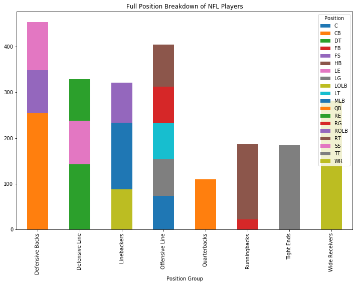

```python
bar_data.plot.bar(stacked=True, subplots=False, figsize=(12,8), title='Full Position Breakdown of NFL Players')
```

This stacked bar graph essentially combines the data from the earlier to pie charts. It gives us a better representation of the frequencies of each positition within each position group. Some quick things we can notice are that defensive backs are the most frequently occurring position group, probably because it contains the Cornerback (CB) position. Running backs get a small boost in numbers from Fullbacks (FB). Fullbacks tend to have slightly different attributes, as some of them are utilized solely as blockers. This is something to keep an eye out for later when we will see if Running Backs are being used optimally.

### 4. Exploratory Data Analysis

As we stated earlier, depending on a player's position, different attributes that are valued differently when it comes to determining the player's overall rating. We grouped players into positional groups because they have a similar skillset. Now, we must create these 'skillsets', by grouping attributes together.

#### 4.1 Attribute Categories

We used this [Madden Wiki link](https://madden.fandom.com/wiki/Attributes) to get a general sense of how we were going to create our attribute categories. The newer version of Madden contained more attributes, so we added those to categories we thought would be fitting. The below block of code simply groups attributes into categories. Here is a brief summary of how we decided to break these up:

- Physical: Any general physical attribute relating to fitness
- Passing: Any attribute relating to throwing power or accuracy
- Rushing: Any attribute relating to carrying the ball and breaking tackles
- Receiving: Any attribute relating to catching the ball and route running
- Blocking: Any attribute relating to blocking defenders
- Pass Rush: Any attribute relating to applying pressure on the Quarterback and/or beating blockers
- Coverage: Any attribute relating to covering a receiver
- General Defense: Any other defensive skill that is useful to have regardless of position (Ex. Tackling)

```python
physical = ['speed rating', 'agility rating','strength rating', 'acceleration rating', 'awareness rating', 'jumping rating', 'stamina rating', 'injury rating']
passing = ['throw power rating', 'throw accuracy short rating', 'throw accuracy deep rating']
rushing = ['carrying rating', 'b c vision rating', 'trucking rating', 'stiff arm rating', 'spin move rating', 'juke move rating', 'elusiveness rating']
receiving = ['catching rating', 'catch in traffic rating', 'short route running rating', 'medium route running rating', 'deep route running rating', 'spectacular catch rating', 'release rating']
blocking = ['run block rating', 'pass block rating', 'impact blocking rating']
pass_rush = ['power moves rating', 'finesse moves rating', 'block shedding rating']
coverage = ['man coverage rating', 'zone coverage rating', 'press rating']
general_defense = ['tackle rating', 'hit power rating', 'play recognition rating', 'pursuit rating']
```

Let us now add these to a dataframe to keep track of these categorical attributes. We will also go ahead and calculate the aggregate rating for each of these attribute groups. We will do this by simply taking the mean of the ratings of the attributes that are contained in each category, and saving them into the categories mentioned in the text above.

```python
df['Physical'] = df[physical].mean(axis=1)
df['Passing'] = df[passing].mean(axis=1)
df['Rushing'] = df[rushing].mean(axis=1)
df['Receiving'] = df[receiving].mean(axis=1)
df['Blocking'] = df[blocking].mean(axis=1)
df['Pass Rush'] = df[pass_rush].mean(axis=1)
df['Coverage'] = df[coverage].mean(axis=1)
df['General Defense'] = df[general_defense].mean(axis=1)
category_ratings_df = df[['Name', 'Team', 'position', 'Rating', 'Physical', 'Passing', 'Rushing', 'Receiving', 'Blocking', 'Pass Rush', 'Coverage', 'General Defense']]
category_ratings_df = category_ratings_df.rename(columns={'position': 'Position'})
category_ratings_df.head(10)
```

|  | Name | Team | Position | Rating | Physical | Passing | Rushing | Receiving | Blocking | Pass Rush | Coverage | General Defense |
| --- | --- | --- | --- | --- | --- | --- | --- | --- | --- | --- | --- | --- |
| 0 | Aaron Donald | LAR | RE | 99 | 90.750 | 10.666667 | 33.142857 | 22.000000 | 61.000000 | 97.333333 | 21.333333 | 93.75 |
| 1 | DeAndre Hopkins | HOU | WR | 99 | 93.375 | 20.000000 | 79.428571 | 96.857143 | 48.666667 | 35.666667 | 35.666667 | 33.75 |
| 2 | Khalil Mack | CHI | LOLB | 99 | 92.250 | 14.666667 | 54.142857 | 31.142857 | 60.000000 | 94.000000 | 52.333333 | 94.00 |
| 3 | Bobby Wagner | SEA | MLB | 99 | 91.125 | 12.333333 | 43.857143 | 20.000000 | 60.000000 | 71.000000 | 67.666667 | 98.75 |
| 4 | Antonio Brown | LV | WR | 98 | 89.750 | 47.000000 | 83.714286 | 95.714286 | 48.000000 | 20.000000 | 16.666667 | 23.25 |
| 5 | Julio Jones | ATL | WR | 98 | 91.250 | 22.000000 | 85.142857 | 96.428571 | 54.333333 | 21.666667 | 20.333333 | 42.25 |
| 6 | Luke Kuechly | CAR | MLB | 98 | 89.750 | 12.333333 | 47.000000 | 30.285714 | 60.333333 | 70.000000 | 69.666667 | 96.50 |
| 7 | David Bakhtiari | GB | LT | 97 | 80.875 | 11.333333 | 14.571429 | 15.285714 | 89.666667 | 13.333333 | 10.000000 | 27.00 |
| 8 | Todd Gurley II | LAR | HB | 97 | 89.375 | 34.666667 | 91.428571 | 59.000000 | 50.666667 | 22.333333 | 14.000000 | 36.25 |
| 9 | Patrick Mahomes | KC | QB | 97 | 85.125 | 94.666667 | 65.714286 | 25.714286 | 10.000000 | 14.666667 | 15.333333 | 25.75 |

#### 4.2 Correlation of Attributes for different positions

Our next step is to find the correlation between the categorical attributes and how they correlate with the overall rating of each position group. As we mentioned earlier, Madden values attributes differently for different positions.

Let us start by first creating dataframes for each position group. These dataframes will contain players with positions of the respective position groups only.

```python
# Create dataframes for each position group
qb_df = df[df['position'].isin(['QB'])]
rb_df = df[df['position'].isin(['HB', 'FB'])]
wr_df = df[df['position'].isin(['WR'])]
te_df = df[df['position'].isin(['TE'])]
ol_df = df[df['position'].isin(['LT', 'LG', 'C', 'RG', 'RT'])]
dl_df = df[df['position'].isin(['LE', 'DT', 'RE'])]
lb_df = df[df['position'].isin(['LOLB','MLB','ROLB'])]
db_df = df[df['position'].isin(['CB', 'FS', 'SS'])]

# Add all position group dataframes to list
position_dfs = [qb_df, rb_df, wr_df, te_df, ol_df, dl_df, lb_df, db_df]
```

Now, we can create correlation matrices for each position group. This will allow us to see the importance of attribute categories on the overall rating of a player for different position groups.

```python
correlations = []
for i in position_dfs:
    rating_categories = i[['Rating', 'Physical', 'Passing', 'Rushing', 'Receiving', 'Blocking', 'Pass Rush', 'Coverage', 'General Defense']]
    rating_categories = rating_categories.corr()
    correlations.append(rating_categories)
```

#### 4.3 Understanding the correlation

Using the correlation matrices that we stored in the correlations array above, we will be plotting correlation heat matrices to provide better visual representation of which attributes affect a position's overall rating. Thankfully Seaborn lets us do this very easily, as we just have to pass in a correlation matrix to generate the table. The higher the correlation coefficient between two variables, the lighter the color is. We will look at the heatmaps for Wide Receivers, Tight Ends and Linebackers, as those seemed to be the most interesting. We are mostly concerned with just the first column, as that shows us the correlation between overall rating and other attribute groups. However, it is interesting to see how the attribute groups can possibly correlate with each other as well!

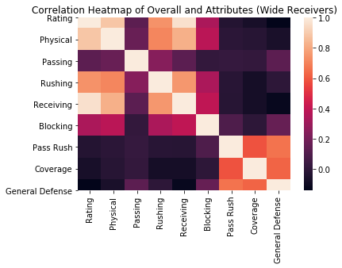

```python
plt.title("Correlation Heatmap of Overall and Attributes (Wide Receivers)", fontsize=12)
sns.heatmap(correlations[2])
```

From the Correlation Heatmap for Wide Receivers, we see that the receiving attribute obviously correlates the most to overall rating, along with physical attributes. What surprised us initially was that the correlation for the rushing attribute was as high as it was. We think this is because most receivers are talented at running with the ball after they make a catch.

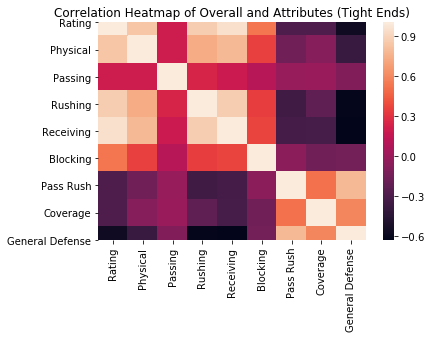

```python
plt.title("Correlation Heatmap of Overall and Attributes (Tight Ends)", fontsize=12)
sns.heatmap(correlations[3])
```

The Heatmap for Tight Ends is quite similar to that of Wide Receivers, except for the fact that the Blocking attribute contributes to overall rating more. We were still surprised at how high the Rushing attributes correlation was.

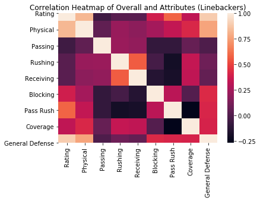

```python
plt.title("Correlation Heatmap of Overall and Attributes (Linebackers)", fontsize=12)
sns.heatmap(correlations[6])
```

We can now look at a defensive position group, Linebackers. The trend we realized was that linebackers ratings depend a lot on General Defense and Physical attributes. They seemed to be a hybrid between the other two defensive position groups. Defensive line seemed to be more dependent on Pass Rush, whereas Defensive Backs were more dependent on Coverage ratings.

Now that we have gotten a good sense of which attributes are important for players of different positions, we will look at the skillsets of players and try and predict what position group their skillset will be a most ideal fit for. We can then compare it with what positions players are currently playing at.

### 5. Machine Learning & Visualization

In this last section, our aim will be to develop a model that can accurately categorize players into positional groups based on their skillset. We believe that because we have many possible position groups that we can classify a player into, using a Linear Discriminant Analysis (LDA) model to categorize players will be an accurate method of doing so. Furthermore, our classification task fits the assumptions of LDA well: the true groups are known already, and we have numerical independent variables (the attributes) and a categorical dependent variable (the predicted category of a given player).

#### 5.1 Creation and Training of Model

First, we will divide our dataframe of players into features and labels.

When we try to fit this model, it is required that we split the data into a training set and test set. Our next step is to break up the players dataframe into these two groups. We will be using a test size of **0.3**.

```python
# Divide player dataframe into features and labels (features are the attributes and labels are the positional group)
Features = df.iloc[:, 73:].to_numpy()
labels = df.iloc[:, 72].to_numpy()

# Use train_test_split to split the data into testing and training data
Features_train, Features_test, labels_train, labels_test = train_test_split(Features, labels, test_size=0.3)
```

Now that we have our data split into testing and training sets, we can use the training data to fit our LDA model. Once fitted, we can use the model to predict position groups for players in the test set. We can then check how accurate our model is.

```python
# Create LDA model and train it on the training dataset
lda = LinearDiscriminantAnalysis()
lda.fit(Features_train, labels_train)

# Make predictions and assess accuracy of the predictions
predictions = lda.predict(Features_test)
print('Accuracy of our LDA model is {}'.format(accuracy_score(labels_test, predictions)))
```

```
Accuracy of our LDA model is 0.9340175953079178
```

**Quite accurate results!**

We tried running this multiple times for consistency, and always received pretty accurate results, typically with an accuracy score in the low to mid 0.9's.

On a side note, if you wanted to learn more about the train test split process, we found this [site](https://www.bitdegree.org/learn/train-test-split) to be pretty helpful!

#### 5.2 Plotting to Observe Differences in Predicted and True Frequencies

Now, it's time to look at the differences in the predicted position groups. Here we will make a bar plot to show the differences in predicted and true frequencies for each positional category. The first step towards making such a plot is to create a nice and tidy dataframe containing the predicted and actual frequencies for each positional category. We will use dictionaries to keep track of the frequencies of each position group for both true and predicted values.

```python
# Build dictionaries containing the predicted and true frequencies of positional groups
prediction_frequencies = {'Quarterbacks':0, 'Runningbacks':0, 'Wide Receivers':0, 'Tight Ends':0, 'Offensive Line':0,
                         'Defensive Line':0, 'Linebackers':0, 'Defensive Backs':0}

true_frequencies = {'Quarterbacks':0, 'Runningbacks':0, 'Wide Receivers':0, 'Tight Ends':0, 'Offensive Line':0,
                         'Defensive Line':0, 'Linebackers':0, 'Defensive Backs':0}

# For each instance of a positional group encountered in the predictions, increase the group's frequency by 1
for prediction in predictions:
    prediction_frequencies[prediction] += 1

# For each instance of a positional group encountered in the test labels, increase the group's frequency by 1
for label in labels_test:
    true_frequencies[label] += 1

# Make a dataframe to hold the frequencies for each position group
# With a row for the prediction and a row for the true positions
frequency_df = pd.DataFrame().append(prediction_frequencies, ignore_index=True).append(true_frequencies, ignore_index=True)
frequency_df
```

|  | Defensive Backs | Defensive Line | Linebackers | Offensive Line | Quarterbacks | Runningbacks | Tight Ends | Wide Receivers |
| --- | --- | --- | --- | --- | --- | --- | --- | --- |
| 0 | 138.0 | 115.0 | 99.0 | 114.0 | 38.0 | 44.0 | 53.0 | 81.0 |
| 1 | 137.0 | 110.0 | 100.0 | 117.0 | 37.0 | 54.0 | 51.0 | 76.0 |

In order to be able to plot what we want, we must transpose this tidy dataframe in order to make a suitable double bar plot. Then, we will pass the new dataframe in and plot our double bar graph.

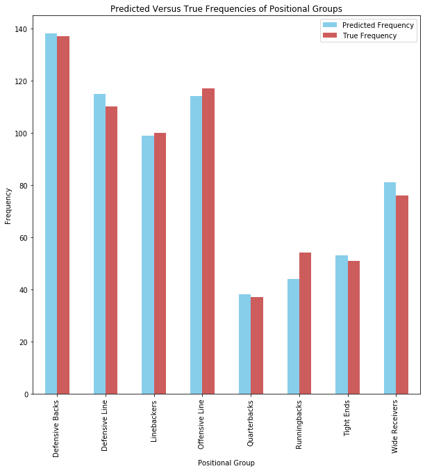

```python
# We need to transpose in order to get the data in a form suitable for plotting with matplotlib
transposed = frequency_df.transpose()
transposed.rename(columns={0:"Predicted Frequency", 1:"True Frequency"}, inplace=True)

# Create a bar chart to show the difference in predicted and true frequencies for positional groups
ax = transposed.plot.bar(color=["SkyBlue", "IndianRed"], title="Predicted Versus True Frequencies of Positional Groups", figsize=(10,10))
ax.set_xlabel("Positional Group")
ax.set_ylabel("Frequency")
matplotlib.rcParams.update({'font.size': 12})
plt.show()
```

### 6. Conclusion

#### 6.1 Recap

With this tutorial, we set out to analyze the positional makeup of the NFL and ultimately see if we could accurately classify NFL players based on their skillset. In order to simplify things, we based our analysis on Madden, an NFL simulation game that seeks to accurately model the skills of NFL players in-game.

We covered a lot of ground in this analysis of NFL player in Madden, so let's do a quick recap of what we did.

We started out by grabbing the dataset. We then removed Kickers and Punters from our data. We do not believe that Madden's attributes are able to meaningfully distinguish between the two positions since Kickers and Punters seem to have very similar attribute profiles.

Next, we analyzed the positional breakdown of our dataset and consolidated positions into positional groups. We did so to simplify classification because positions within a positional group tend to have similar attribute profiles.

We then looked at the correlation between the attributes and overall rating for players in three different positional groups: Wide Receivers, Tight Ends, and Linebackers. We analyzed each group separately because Madden values attributes differently for different positional groups. For example, from the heat maps, we can tell that Wide Receiver's overall rating is highly correlated with their receiving attribute, but for Linebackers, their receiving attribute has very little correlation to their overall rating.

#### 6.2 Final Thoughts

Thank you for reading! We hope you enjoyed the tutorial and learned something along the way!